# LGEO2185: Session ? – RF classification with tidymodels

## 9. Tune the model (fit across folds)

We select metrics that are appropriate for classification.

- F1 metric (`f_meas`)

> F1 score measure the harmonic mean of precision and recall. An introduction to classification performance metrics can be found [here](https://developers.google.com/machine-learning/crash-course/classification/accuracy-precision-recall).

```r
rf_metrics <- metric_set(f_meas)

set.seed(42)
rf_tune <- tune_grid(
  rf_workflow,
  resamples = kasai_folds,
  grid      = rf_grid,
  metrics   = rf_metrics,
  control   = control_grid(save_pred = TRUE)
)

rf_tune
```

```
# Tuning results
# 5-fold cross-validation using stratification
# A tibble: 5 × 5
  splits            id    .metrics          .notes           .predictions
  <list>            <chr> <list>            <list>           <list>
1 <split [839/213]> Fold1 <tibble [64 × 7]> <tibble [0 × 4]> <tibble>
2 <split [840/212]> Fold2 <tibble [64 × 7]> <tibble [0 × 4]> <tibble>
3 <split [842/210]> Fold3 <tibble [64 × 7]> <tibble [0 × 4]> <tibble>
4 <split [843/209]> Fold4 <tibble [64 × 7]> <tibble [0 × 4]> <tibble>
5 <split [844/208]> Fold5 <tibble [64 × 7]> <tibble [0 × 4]> <tibble>
```

### 9.1 Visualize tuning results

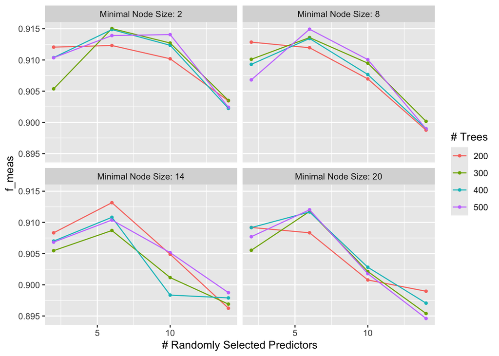

```r
autoplot(rf_tune)
```

### 9.2 Select the best model

```r
best_params <- select_best(rf_tune, metric = "f_meas")
best_params
```

```
# A tibble: 1 × 4
   mtry trees min_n .config
  <int> <int> <int> <chr>
1     6   300     2 pre0_mod21_post0
```

## 10. Finalize workflow + evaluate on the test set

```r
rf_final_workflow <- finalize_workflow(rf_workflow, best_params)

test_model_fit <- last_fit(rf_final_workflow, split = kasai_split, metrics = rf_metrics)

test_model_fit
```

```
# Resampling results
# Manual resampling
# A tibble: 1 × 6
  splits             id               .metrics .notes   .predictions .workflow
  <list>             <chr>            <list>   <list>   <list>       <list>
1 <split [1052/266]> train/test split <tibble> <tibble> <tibble>     <workflow>
```

### 10.1 Test-set metrics

```r
collect_metrics(test_model_fit)
```

```
# A tibble: 1 × 4
  .metric .estimator .estimate .config
  <chr>   <chr>          <dbl> <chr>
1 f_meas  macro          0.892 pre0_mod0_post0
```

### 10.2 Confusion matrix

```r
test_preds <- collect_predictions(test_model_fit)

test_preds %>%
  conf_mat(truth = class, estimate = .pred_class)
```

```
          Truth
Prediction built_up cropland forest savannah water
  built_up       36        1      0        0     0
  cropland        7       63      0        8     0
  forest          0        0     48        2     2
  savannah        0        9      2       43     0
  water           0        0      0        0    45
```

What can we learn from this confusion matrix?

## 11. Fit final model on all data (for deployment)

Once you’re satisfied, we refit on **all labeled data** (train + test combined) before we deploy for mapping. Think about this: what is the difference between tuning, performance reporting and inference?

```r
final_model_fit <- fit(rf_final_workflow, data = bind_rows(kasai_train2, kasai_test2))

final_model_fit
```

```
══ Workflow [trained] ══════════════════════════════════════════════════════════
Preprocessor: Recipe
Model: rand_forest()

── Preprocessor ────────────────────────────────────────────────────────────────
3 Recipe Steps

• step_zv()
• step_nzv()
• step_impute_median()

── Model ───────────────────────────────────────────────────────────────────────
Ranger result

Call:
 ranger::ranger(x = maybe_data_frame(x), y = y, mtry = min_cols(~6L,      x), num.trees = ~300L, min.node.size = min_rows(~2L, x),      importance = ~"impurity", num.threads = 1, verbose = FALSE,      seed = sample.int(10^5, 1), probability = TRUE)

Type:                             Probability estimation
Number of trees:                  300
Sample size:                      1318
Number of independent variables:  14
Mtry:                             6
Target node size:                 2
Variable importance mode:         impurity
Splitrule:                        gini
OOB prediction error (Brier s.):  0.07992714
```

## 12. Variable importance (interpretation)

Variable importance is one of the simplest ways to connect “black-box” models back to domain reasoning. This variable importance assessment is a key interpretation step in machine learning.

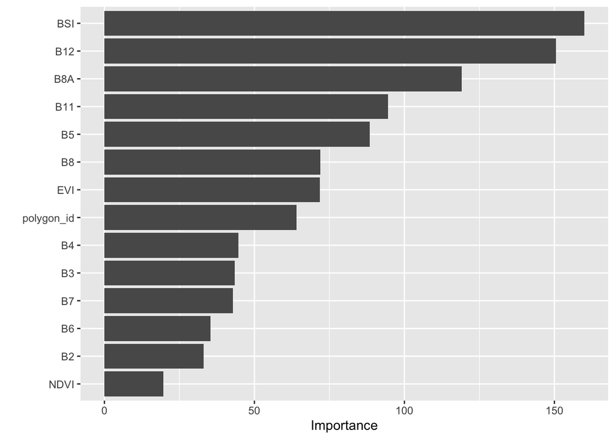

```r
# Extract the fitted parsnip model
rf_engine_fit <- final_model_fit  %>% extract_fit_parsnip()

# Plot variable importance
vip::vip(rf_engine_fit, num_features = 20)
```

> - Which predictors make sense for separating your classes?
> - Are any “top predictors” suspicious ? 😇
> - Do the top predictors match your conceptual understanding of the landscape?

## 13. Reduced RF model

```r
  ## ---- Reduced RF model evaluated like Section 10 (using last_fit) ----

# 0) Manually choose predictors from VIP plot
top_vars <- c("B12", "B11", "BSI", "B5", "B8A","B8")
kasai_train2_reduced <- kasai_train2 %>%
  dplyr::select(class, all_of(top_vars))

# 1) Reduced recipe
rf_recipe_reduced <- recipe(class ~ ., data = kasai_train2_reduced) %>%
  step_zv(all_predictors()) %>%
  step_nzv(all_predictors()) %>%
  step_impute_median(all_numeric_predictors())

# 2) Reduced workflow (reuse tuned hyperparameters)
rf_workflow_reduced <- workflow() %>%
  add_recipe(rf_recipe_reduced) %>%
  add_model(rf_model)

rf_final_workflow_reduced <- finalize_workflow(rf_workflow_reduced, best_params)

# 3) Evaluate on test set with last_fit (same approach as Section 10)
test_model_reduced_fit <- last_fit(rf_final_workflow_reduced, split = kasai_split, metrics = rf_metrics)

# 4) Confusion matrix + metrics (same as Section 10)
test_preds_reduced <- collect_predictions(test_model_reduced_fit)

test_preds_reduced %>%
  conf_mat(truth = class, estimate = .pred_class)
```

```
          Truth
Prediction built_up cropland forest savannah water
  built_up       35        2      0        0     0
  cropland        8       58      0       10     0
  forest          0        0     47        1     2
  savannah        0       13      3       42     0
  water           0        0      0        0    45
```

```r
collect_metrics(test_model_reduced_fit)
```

```
# A tibble: 1 × 4
  .metric .estimator .estimate .config
  <chr>   <chr>          <dbl> <chr>
1 f_meas  macro          0.866 pre0_mod0_post0
```

```r
final_reduced_model_fit <- fit(
  rf_final_workflow_reduced,
  data = bind_rows(
    kasai_train2 %>% dplyr::select(class, all_of(top_vars)),
    kasai_test2  %>% dplyr::select(class, all_of(top_vars))
  )
)

metrics_full    <- collect_metrics(test_model_fit) %>% mutate(model = "Full RF")
metrics_reduced <- collect_metrics(test_model_reduced_fit) %>% mutate(model = "Reduced RF")

model_comparison <- bind_rows(metrics_full, metrics_reduced) %>%
  select(model, .metric, .estimate) %>%
  tidyr::pivot_wider(names_from = model, values_from = .estimate)

model_comparison
```

```
# A tibble: 1 × 3
  .metric `Full RF` `Reduced RF`
  <chr>       <dbl>        <dbl>
1 f_meas      0.892        0.866
```

## 14. Inference: mapping predictions with terra

- load the raster stack
- make sure layer names match your top_vars predictor names
- convert raster values → data.frame
- predict() with the workflow (class + probs)
- write results back to rasters and export GeoTIFFs

Here’s an inference block:

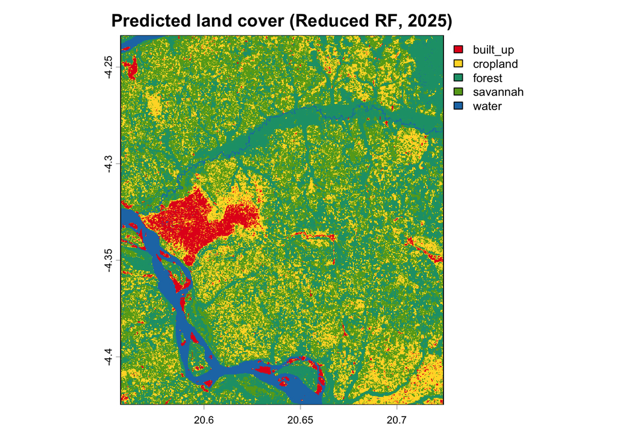

```r
# 1) Load predictor raster stack (must contain layers named like top_vars)
r <- rast("GEE_Exports_Annual/s2_composite_2025.tif")
# Keep only the predictors used by the reduced model
r_red <- r[[top_vars]]

# 2) Predict land-cover classes with the tidymodels fitted workflow

r_class <- terra::predict(
r_red,
model = final_reduced_model_fit,
type = "class",
na.rm = TRUE,
filename = "GEE_Exports_Annual/RF_reduced_class_2025.tif",
overwrite = TRUE
)

cat_tab <- levels(r_class)[[1]]
lab_col <- names(cat_tab)[2]
labs <- as.character(cat_tab[[lab_col]])

lc_cols <- c(
  built_up = "#e31a1c",
  cropland = "#FFD92F",
  forest   = "#1b9e77",
  savannah = "#66a61e",
  water    = "#1f78b4"
)

cols <- unname(lc_cols[labs])
cols[is.na(cols)] <- "grey70"

plot(r_class, col = cols, main = "Predicted land cover (Reduced RF, 2025)")
```

**Note**

Recipes prepare data, workflows train models, tuning chooses parameters, last_fit() evaluates once, and final fit() is what we deploy.

| **Stage** | **Object name** | **Package** | **What it represents** | **Used for** |
| --- | --- | --- | --- | --- |
| **Data split** | `kasai_split` | `rsample` | Definition of training vs test data | Reproducible splitting |
|  | `kasai_train` | `rsample` | Training data table | Model learning |
|  | `kasai_test` | `rsample` | Test data table | Final evaluation |
|  | `kasai_folds` | `rsample` | Cross-validation folds | Hyperparameter tuning |
| **Preprocessing** | `rf_recipe` | `recipes` | Full preprocessing pipeline | Feature preparation |
|  | `rf_recipe_reduced` | `recipes` | Reduced-predictor pipeline | Feature selection |
| **Model spec** | `rf_model` | `parsnip` | Random Forest definition + tunable parameters | Model type only (no data) |
| **Workflow** | `rf_workflow` | `workflows` | Recipe + model (full) | Tuning, fitting |
|  | `rf_workflow_reduced` | `workflows` | Recipe + model (reduced) | Reduced modelling |
| **Tuning** | `rf_tune` | `tune` | CV performance for many parameter sets | Model selection |
|  | `best_params` | `tune` | Best hyperparameter combination | Freezing complexity |
| **Finalized workflow** | `rf_final_workflow` | `workflows` | Tuned & locked full workflow | Ready for fitting |
|  | `rf_final_workflow_reduced` | `workflows` | Tuned & locked reduced workflow | Ready for fitting |
| **Test evaluation** | `test_model_fit` | `yardstick` | Test-set performance (full) | Reporting only |
|  | `test_model_reduced_fit` | `yardstick` | Test-set performance (reduced) | Model comparison |
| **Deployment** | `final_model_fit` | `parsnip` | Full model trained on all data | Inference / mapping |
|  | `final_reduced_model_fit` | `parsnip` | Reduced model trained on all data | Inference / mapping |
| **Prediction output** | `r_class` | `terra` | Raster of predicted classes | Mapping / analysis |

## 15. Neural networks

This session also introduces land-cover classification with neural networks as an alternative to Random Forest.

```r
library(tidymodels)
library(nnet)

nn_recipe <- recipe(class ~ ., data = kasai_train2) %>%
  step_zv(all_predictors()) %>%
  step_normalize(all_numeric_predictors())

nn_model <- mlp(
  mode = "classification",
  hidden_units = 10,
  penalty = 0.001,
  epochs = 200
) %>%
  set_engine("nnet", trace = FALSE)

nn_workflow <- workflow() %>%
  add_recipe(nn_recipe) %>%
  add_model(nn_model)

nn_final_workflow <- nn_workflow

nn_test_model_fit <- last_fit(nn_final_workflow, split = kasai_split, metrics = rf_metrics)
nn_test_model_fit
```

```
# Resampling results
# Manual resampling
# A tibble: 1 × 6
  splits             id               .metrics .notes   .predictions .workflow
  <list>             <chr>            <list>   <list>   <list>       <list>
1 <split [1052/266]> train/test split <tibble> <tibble> <tibble>     <workflow>
```

```r
nn_test_preds <- collect_predictions(nn_test_model_fit)

conf_mat(nn_test_preds, truth = class, estimate = .pred_class)
```

```
          Truth
Prediction built_up cropland forest savannah water
  built_up       37        5      0        1     0
  cropland        4       58      0        9     0
  forest          0        0     48        0     1
  savannah        2       10      2       43     0
  water           0        0      0        0    46
```

```r
collect_metrics(nn_test_model_fit)
```

```
# A tibble: 1 × 4
  .metric .estimator .estimate .config
  <chr>   <chr>          <dbl> <chr>
1 f_meas  macro          0.881 pre0_mod0_post0
```

```r
nn_final_model_fit <- fit(nn_final_workflow, data = bind_rows(kasai_train2, kasai_test2))
nn_final_model_fit
```

```
══ Workflow [trained] ══════════════════════════════════════════════════════════
Preprocessor: Recipe
Model: mlp()

── Preprocessor ────────────────────────────────────────────────────────────────
2 Recipe Steps

• step_zv()
• step_normalize()

── Model ───────────────────────────────────────────────────────────────────────
a 14-10-5 network with 205 weights
inputs: polygon_id B2 B3 B4 B5 B6 B7 B8 B8A B11 B12 BSI NDVI EVI
output(s): ..y
options were - softmax modelling  decay=0.001
```